# Loan Prediction Problem

Problem Statement

Hypothesis Generation

Getting the system ready and loading the data

Understanding the data

Exploratory Data Analysis (EDA)

Univariate Analysis

Bivariate Analysis

Model Building : Part I

Model Building : Part II

Logistic Regression

XGBoost

# Understand the Problem Statement

Dream Housing Finance company deals in all home loans. They have presence across all urban, semi urban and rural areas. Customer first apply for home loan after that company validates the customer eligibility for loan.

Company wants to automate the loan eligibility process (real time) based on customer detail provided while filling online application form. These details are Gender, Marital Status, Education, Number of Dependents, Income, Loan Amount, Credit History and others.

To automate this process, they have given a problem to identify the customers segments, those are eligible for loan amount so that they can specifically target these customers.

Loan prediction is a very common real-life problem that each retail bank faces atleast once in its lifetime. If done correctly, it can save a lot of man hours at the end of a retail bank.

# Data Dictionary

Variable Description

Loan_ID - Unique Loan ID

Gender - Male/ Female

Married - Applicant married (Y/N)

Dependents - Number of dependents

Education - Applicant Education (Graduate/ Under Graduate)

Self_Employed - Self employed (Y/N)

ApplicantIncome - Applicant income

CoapplicantIncome - Coapplicant income

LoanAmount - Loan amount in thousands

Loan_Amount_Term - Term of loan in months

Credit_History - credit history meets guidelines

Property_Area - Urban/ Semi Urban/ Rural

Loan_Status - Loan approved (Y/N)

# Lets Talk About Hypothesis Generation

This is a very important stage in any data science/machine learning pipeline. It involves understanding the problem in detail by brainstorming as many factors as possible which can impact the outcome. It is done by understanding the problem statement thoroughly and before looking at the data.

Below are some of the factors which I think can affect the Loan Approval (dependent variable for this loan prediction problem):

Salary: Applicants with high income should have more chances of loan approval.

Previous history: Applicants who have repayed their previous debts should have higher chances of loan approval.

Loan amount: Loan approval should also depend on the loan amount.

If the loan amount is less, chances of loan approval should be high.

Loan term: Loan for less time period and less amount should have higher chances of approval.

EMI: Lesser the amount to be paid monthly to repay the loan, higher the chances of loan approval.

These are some of the factors which i think can affect the target variable, you can come up with many more factors.

```python
# Import all the required libraries
import pandas as pd
import numpy as np
import matplotlib.pyplot as plt # Data Visualization
```

```python
# Importing the Data in Python

train = pd.read_csv("~/Downloads/train_u6lujuX_CVtuZ9i.csv")
test = pd.read_csv("~/Downloads/test_Y3wMUE5_7gLdaTN.csv")
```

```python
# Find out the Train and test Columns
train.columns
```

```
Index(['Loan_ID', 'Gender', 'Married', 'Dependents', 'Education',
       'Self_Employed', 'ApplicantIncome', 'CoapplicantIncome', 'LoanAmount',
       'Loan_Amount_Term', 'Credit_History', 'Property_Area', 'Loan_Status'],
      dtype='object')
```

```python
# Loan Status is the TARGET Variable
test.columns
```

```
Index(['Loan_ID', 'Gender', 'Married', 'Dependents', 'Education',
       'Self_Employed', 'ApplicantIncome', 'CoapplicantIncome', 'LoanAmount',
       'Loan_Amount_Term', 'Credit_History', 'Property_Area'],
      dtype='object')
```

# Exploratory Data Analysis

```python
train.head()
```

|  | Loan_ID | Gender | Married | Dependents | Education | Self_Employed | ApplicantIncome | CoapplicantIncome | LoanAmount | Loan_Amount_Term | Credit_History | Property_Area | Loan_Status |
| --- | --- | --- | --- | --- | --- | --- | --- | --- | --- | --- | --- | --- | --- |
| 0 | LP001002 | Male | No | 0 | Graduate | No | 5849 | 0.0 | NaN | 360.0 | 1.0 | Urban | Y |
| 1 | LP001003 | Male | Yes | 1 | Graduate | No | 4583 | 1508.0 | 128.0 | 360.0 | 1.0 | Rural | N |
| 2 | LP001005 | Male | Yes | 0 | Graduate | Yes | 3000 | 0.0 | 66.0 | 360.0 | 1.0 | Urban | Y |
| 3 | LP001006 | Male | Yes | 0 | Not Graduate | No | 2583 | 2358.0 | 120.0 | 360.0 | 1.0 | Urban | Y |
| 4 | LP001008 | Male | No | 0 | Graduate | No | 6000 | 0.0 | 141.0 | 360.0 | 1.0 | Urban | Y |

## Univariate Analysis - Categorical Variables

```python
# Target Variable

train["Loan_Status"].value_counts() # Actual Count of Values
```

```
Y    422
N    192
Name: Loan_Status, dtype: int64
```

```python
# Proportion of Values
train["Loan_Status"].value_counts(normalize=True)
```

```
Y    0.687296
N    0.312704
Name: Loan_Status, dtype: float64
```

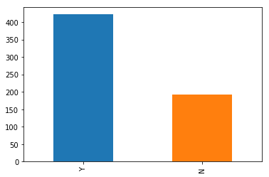

```python
# Create a Barplot
train["Loan_Status"].value_counts().plot.bar()
```

```python
# Find out the cat variables
train.dtypes
```

```
Loan_ID               object
Gender                object
Married               object
Dependents            object
Education             object
Self_Employed         object
ApplicantIncome        int64
CoapplicantIncome    float64
LoanAmount           float64
Loan_Amount_Term     float64
Credit_History       float64
Property_Area         object
Loan_Status           object
dtype: object
```

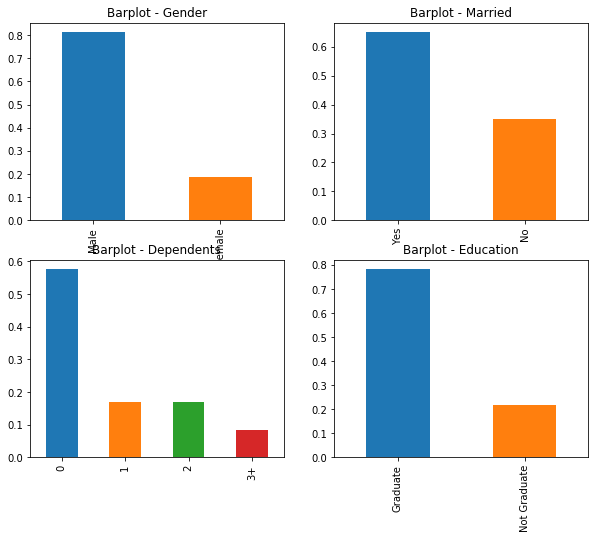

```python
# Create a Barplot of these variables
plt.subplot(221) # 2 rep two rows, 2 rep col, 1 rep my index of plot
train["Gender"].value_counts(normalize=True).plot.bar(figsize=(10,8), title = "Barplot - Gender")

plt.subplot(222) # 2 rep two rows, 2 rep col, 1 rep my index of plot
train["Married"].value_counts(normalize=True).plot.bar(title = "Barplot - Married")

plt.subplot(223) # 2 rep two rows, 2 rep col, 1 rep my index of plot
train["Dependents"].value_counts(normalize=True).plot.bar(title = "Barplot - Dependents")

plt.subplot(224) # 2 rep two rows, 2 rep col, 1 rep my index of plot
train["Education"].value_counts(normalize=True).plot.bar(title = "Barplot - Education")

plt.show()
```

# Inference

1. Males are more than females
2. Married people are more and bachelors are almost ~35%.
3. Lot of People dont have dependents and max value is 3+
4. Mostly Graduates

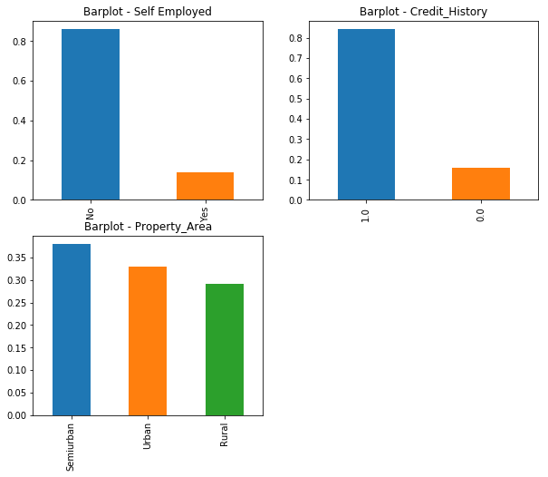

```python
# Create a Barplot of remaining  variables
plt.subplot(221) # 2 rep two rows, 2 rep col, 1 rep my index of plot
train["Self_Employed"].value_counts(normalize=True).plot.bar(figsize=(10,8), title = "Barplot - Self Employed")

plt.subplot(222) # 2 rep two rows, 2 rep col, 1 rep my index of plot
train["Credit_History"].value_counts(normalize=True).plot.bar(title = "Barplot - Credit_History")

plt.subplot(223) # 2 rep two rows, 2 rep col, 1 rep my index of plot
train["Property_Area"].value_counts(normalize=True).plot.bar(title = "Barplot - Property_Area")
```

1. Mostly Salaried Class is visible
2. Nearly 0.8 people repay their loan.
3. Most of the loans are requested for Semi Urban and Urban Properties...

## Univariate Analysis - Numerical Variables

```python
train.dtypes
```

```
Loan_ID               object
Gender                object
Married               object
Dependents            object
Education             object
Self_Employed         object
ApplicantIncome        int64
CoapplicantIncome    float64
LoanAmount           float64
Loan_Amount_Term     float64
Credit_History       float64
Property_Area         object
Loan_Status           object
dtype: object
```

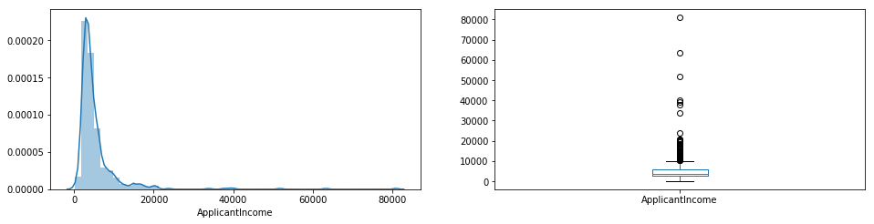

```python
import seaborn as sns

plt.subplot(221)
sns.distplot(train["ApplicantIncome"])

plt.subplot(222)
train["ApplicantIncome"].plot.box(figsize = (16,8))
```

Applicant Income is Highly Skewed Figure and lot of Outliers are also visualised.

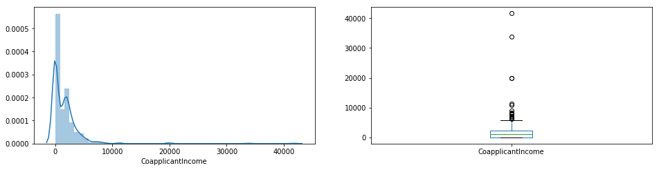

```python
plt.subplot(221)
sns.distplot(train["CoapplicantIncome"])

plt.subplot(222)
train["CoapplicantIncome"].plot.box(figsize = (16,8))
```

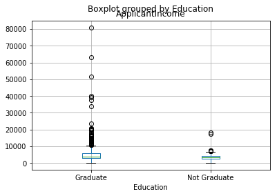

```python
# Boxplot of Applicant Income Using Education
train.boxplot(column="ApplicantIncome", by = "Education")
```

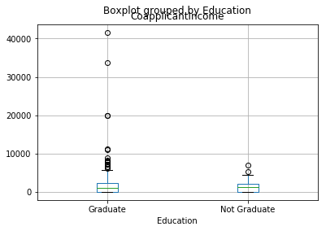

```python
# Boxplot of CoapplicantIncome by Education
train.boxplot(column="CoapplicantIncome", by = "Education")
```

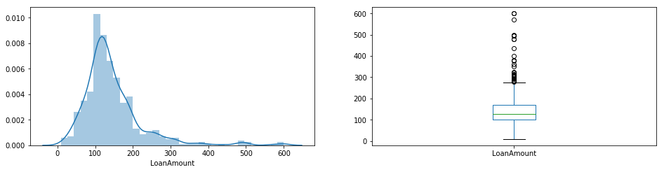

```python
# LoanAmount
train = train.dropna()
plt.subplot(221)
sns.distplot(train["LoanAmount"])

plt.subplot(222)
train["LoanAmount"].plot.box(figsize = (16,8))
```

# Bivariate Analysis

```python
train.dtypes
```

```
Loan_ID               object
Gender                object
Married               object
Dependents            object
Education             object
Self_Employed         object
ApplicantIncome        int64
CoapplicantIncome    float64
LoanAmount           float64
Loan_Amount_Term     float64
Credit_History       float64
Property_Area         object
Loan_Status           object
dtype: object
```

```python
# Cat Var vs Target Variable - Gender Vs Loan Status
gender_loan = pd.crosstab(train["Gender"], train["Loan_Status"])
```

```python
gender_loan
```

| Loan_Status Gender | N | Y |
| --- | --- | --- |
| Female | 32 | 54 |
| Male | 116 | 278 |

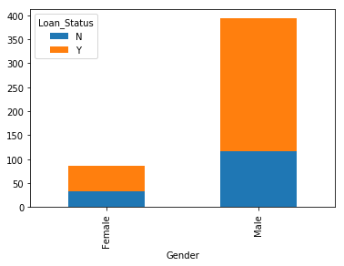

```python
gender_loan.plot(kind="bar", stacked = True)
```

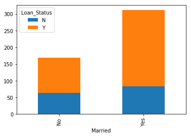

```python
# Cat Var vs Target Variable - Married Vs Loan Status
married_loan = pd.crosstab(train["Married"], train["Loan_Status"])
married_loan.plot(kind="bar", stacked = True)
```

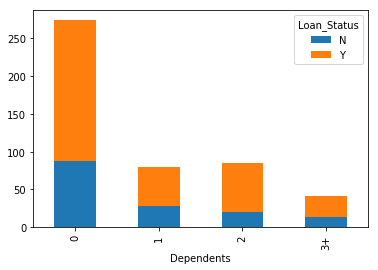

```python
# Cat Var vs Target Variable - Married Vs Loan Status
dep_loan = pd.crosstab(train["Dependents"], train["Loan_Status"])
dep_loan.plot(kind="bar", stacked = True)
```

Most Loans are visible with 0 Dependents. Least Loans are with 3+ dependents

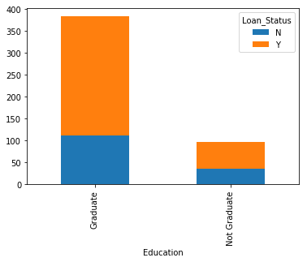

```python
# Education
edu_loan = pd.crosstab(train["Education"], train["Loan_Status"])
edu_loan.plot(kind="bar", stacked = True)
```

Graduates get more loan than Non Graduate Folks

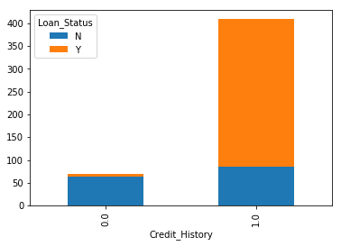

```python
# Cat Var vs Target Variable - Married Vs Loan Status
Credit_History_loan = pd.crosstab(train["Credit_History"], train["Loan_Status"])
Credit_History_loan.plot(kind="bar", stacked = True)
```

Higher Credit History Leads to More Chances of Getting Debt

```python
train["ApplicantIncome"].describe()
```

```
count      480.000000
mean      5364.231250
std       5668.251251
min        150.000000
25%       2898.750000
50%       3859.000000
75%       5852.500000
max      81000.000000
Name: ApplicantIncome, dtype: float64
```

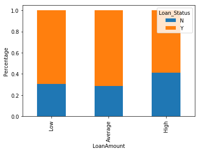

```python
bins=[0,100,200,700]
group=['Low','Average','High']
train['LoanAmount_bin']=pd.cut(train['LoanAmount'],bins,labels=group)

LoanAmount_bin=pd.crosstab(train['LoanAmount_bin'],train['Loan_Status'])
LoanAmount_bin.div(LoanAmount_bin.sum(1).astype(float), axis=0).plot(kind="bar", stacked=True)
plt.xlabel('LoanAmount')
P = plt.ylabel('Percentage')
```

```python
# replacing 3+ in Dependents variable with 3
# replacing Y and N in Loan_Status variable with 1 and 0 respectively
train['Dependents'].replace(('0', '1', '2', '3+'), (0, 1, 2, 3),inplace=True)
test['Dependents'].replace(('0', '1', '2', '3+'), (0, 1, 2, 3),inplace=True)
train['Loan_Status'].replace('N', 0,inplace=True)
train['Loan_Status'].replace('Y', 1,inplace=True)
```

```python
from sklearn.tree import DecisionTreeClassifier
tree = DecisionTreeClassifier()
```

# Missing Values

```python
train.isnull().sum()
```

```
Loan_ID              0
Gender               0
Married              0
Dependents           0
Education            0
Self_Employed        0
ApplicantIncome      0
CoapplicantIncome    0
LoanAmount           0
Loan_Amount_Term     0
Credit_History       0
Property_Area        0
Loan_Status          0
LoanAmount_bin       0
dtype: int64
```

```python
# Categorical Columns
train["Gender"].fillna(train["Gender"].mode()[0], inplace=True)
train["Married"].fillna(train["Married"].mode()[0], inplace=True)
train["Dependents"].fillna(train["Dependents"].mode()[0], inplace=True)
train["Self_Employed"].fillna(train["Self_Employed"].mode()[0], inplace=True)
```

```python
train["Loan_Amount_Term"].value_counts()
```

```
360.0    411
180.0     36
480.0     12
300.0      9
84.0       3
120.0      3
36.0       2
240.0      2
60.0       2
Name: Loan_Amount_Term, dtype: int64
```

```python
train["Loan_Amount_Term"].fillna(train["Loan_Amount_Term"].mode()[0], inplace=True)
```

```python
train["Credit_History"].value_counts()
```

```
1.0    410
0.0     70
Name: Credit_History, dtype: int64
```

```python
train["Credit_History"].fillna(train["Credit_History"].mode()[0], inplace=True)
```

```python
train["LoanAmount"].describe() # Numerical Column
```

```
count    480.000000
mean     144.735417
std       80.508164
min        9.000000
25%      100.000000
50%      128.000000
75%      170.000000
max      600.000000
Name: LoanAmount, dtype: float64
```

```python
train["LoanAmount"].fillna(train["LoanAmount"].median(), inplace=True)
```

```python
train.isnull().sum()
```

```
Loan_ID              0
Gender               0
Married              0
Dependents           0
Education            0
Self_Employed        0
ApplicantIncome      0
CoapplicantIncome    0
LoanAmount           0
Loan_Amount_Term     0
Credit_History       0
Property_Area        0
Loan_Status          0
LoanAmount_bin       0
dtype: int64
```

```python
# Missing Values in test

test["Gender"].fillna(test["Gender"].mode()[0], inplace=True)
test["Married"].fillna(test["Married"].mode()[0], inplace=True)
test["Dependents"].fillna(test["Dependents"].mode()[0], inplace=True)
test["Self_Employed"].fillna(test["Self_Employed"].mode()[0], inplace=True)
test["Loan_Amount_Term"].fillna(test["Loan_Amount_Term"].mode()[0], inplace=True)
test["LoanAmount"].describe() # Numerical Column
test["LoanAmount"].fillna(test["LoanAmount"].median(), inplace=True)
test["Credit_History"].fillna(test["Credit_History"].mode()[0], inplace=True)
```

```python
test.isnull().sum()
```

```
Loan_ID              0
Gender               0
Married              0
Dependents           0
Education            0
Self_Employed        0
ApplicantIncome      0
CoapplicantIncome    0
LoanAmount           0
Loan_Amount_Term     0
Credit_History       0
Property_Area        0
dtype: int64
```

```python
# Apply One Hot Encoding
train = pd.get_dummies(train)
test = pd.get_dummies(test)
test = test.drop("Loan_ID", axis = 1)
```

```python
test = pd.get_dummies(test)
```

```python
x = train.drop("Loan_Status", axis=1)
y = train["Loan_Status"]
```

```python
x=pd.get_dummies(x)
train=pd.get_dummies(train)
test=pd.get_dummies(test)
```

```python
from sklearn.model_selection import train_test_split
from sklearn.linear_model import LogisticRegression
from sklearn.metrics import accuracy_score
x_train, x_cv, y_train, y_cv = train_test_split(x,y, test_size =0.3)
```

```python
model = LogisticRegression()
```

```python
log_model = model.fit(x_train, y_train)
```

```python
log_predict = model.predict(x_cv)
```

```python
accuracy_score(y_cv, log_predict)
```

```
0.8333333333333334
```

```python
!pip install xgboost
```

[output not shown]

```python
from xgboost import XGBClassifier
```

```python
xgboost = XGBClassifier()
```

```python
model_xg = xgboost.fit(x_train, y_train)
```

```python
pred_xgboost = xgboost.predict(x_cv)
```

```python
accuracy_score(y_cv, pred_xgboost)
```

```
0.8125
```

```python
submission['Loan_Status']=pred_test
submission['Loan_ID']=test_original['Loan_ID']
```

```python
submission['Loan_Status'].replace(0, 'N',inplace=True)
submission['Loan_Status'].replace(1, 'Y',inplace=True)
```

```python
pd.DataFrame(submission, columns=['Loan_ID','Loan_Status']).to_csv('XGB.csv')
```